# WUM Projekt nr 1

Bartłomiej Granat, Piotr Miziński

30 - 04 - 2019

# 1 Wstęp

W naszym projekcie podjęliśmy się przewidywania szansy recydywizmu u więźnia na podstawie danych Compass. Po przeprowadzeniu eksploracji danych i inżynierii cech testowaliśmy działanie róznych modeli klasyifkacyjnych. Na koniec zajęliśmy się dopasowywaniem hiperparametrów. Wnioski przedstawione są w poniższym raporcie

Na samym początku przyjrzeliśmy się słownikowi zmiennych, aby wybrać te, które wykorzystamy do predykcji.

| Variable | Description |
| --- | --- |
| id | unque identifier for each individual |
| name | first and last name |
| first | first name |
| last | last name |
| compas_screening_dat | date on which decile_score was given |
| sex | sex (male or female) |
| dob | date of birth |
| age | age in years |
| age_cat | age category (less than 25, 25-45, greater than 45) |
| race | race (African-American, Asian, Caucasian, Hispanic, Native American, Other) |
| juv_fel_count | juvenile felony count |
| decile_score | COMPAS Risk of Recidivism score from 1 to 10 |
| juv_misd_count | juvenile misdemeanor count |
| juv_other_count | juvenile other offenses count |
| priors_count | prior offenses count |
| days_b_screening_arrest | number of days between COMPAS screening and arrest |
| c_jail_in | jail entry date for original crime |
| c_jail_out | jail exit date for original crime |
| c_case_number | case number for original crime |
| c_offense_date | offense date of original crime |
| c_arrest_date | arrest date for original crime |
| c_days_from_compas | days between COMPAS screening and original crime offense date |
| c_charge_degree | charge degree of original crime |
| c_charge_desc | description of charge for original crime |
| is_recid | binary indicator of recidivation (1=individual recidivated, 0=individual did not recidivate) |
| r_case_number | case number of follow-up crime |
| r_charge_degree | charge degree of follow-up crime |
| r_days_from_arrest | number of days between follow-up crime and arrest date |
| r_offense_date | date of follow-up crime |
| r_charge_desc | description of charge for follow-up crime |
| r_jail_in | jail entry date for follow-up crime |
| r_jail_out | jail exit date for follow-up crime |
| violent_recid | values are all `NA`. This column is ignored. |
| is_voilent_recid | binary indicator of violent follow-up crime (1=follow-up crime was violent, 0=follow-up crime was non-violent) |
| vr_case_number | case number for violent follow-up crime |
| vr_charge_degree | charge degree for violent follow-up crime |
| vr_offense_date | date of offense for violent follow-up crime |
| vr_charge_desc | description of charge for violent follow-up crime |
| type_of_assessment | the type of COMPAS score given for decile_score (here all values are Risk of Recidivism) |
| decile_score.1 | repeat column of decile_score |
| score_text | ProPublica-defined category of decile_score (High=8-10, Medium=5-7, Low=1-4) |
| screening_date | repeat column of compas_screening_date |
| v_type_of_assessment | the type of COMPAS score given for v_decile_score (here all values are Risk_of_Violence) |
| v_decile_score | COMPAS Risk of Violence score from 1 to 10 |
| v_score_text | ProPublica-defined category of v_decile_score (High=8-10, Medium=5-7, Low=1-4) |
| v_screening_date | date on which v_decile_score was given |
| in_custody | date on which individual was brought into custody |
| out_custody | date on which individual was released from custody |
| priors_count.1 | repeat column of priors_count |
| two_year_recid | binary indicator of recidivation within two years of scoring (1=individual recidivated, 0=individual did not recidivate) |
| start | unclear definition but not used in our analysis |
| end | unclear definition but not used in our analysis |
| event | unclear definition but not used in our analysis |

Wszystkie kolumny związane z badaniem Compass nas nie interesują, ponieważ zawierają dane o tym co zamierzamy przewidywać. Po usunięciu tych zmiennych zrobiliśmy pierwszą wizualizację danych.

```r
introduce(df1)
```

```
##    rows columns discrete_columns continuous_columns all_missing_columns
## 1 10331      17               11                  6                   0
##   total_missing_values complete_rows total_observations memory_usage
## 1                11288             0             175627      3252024
```

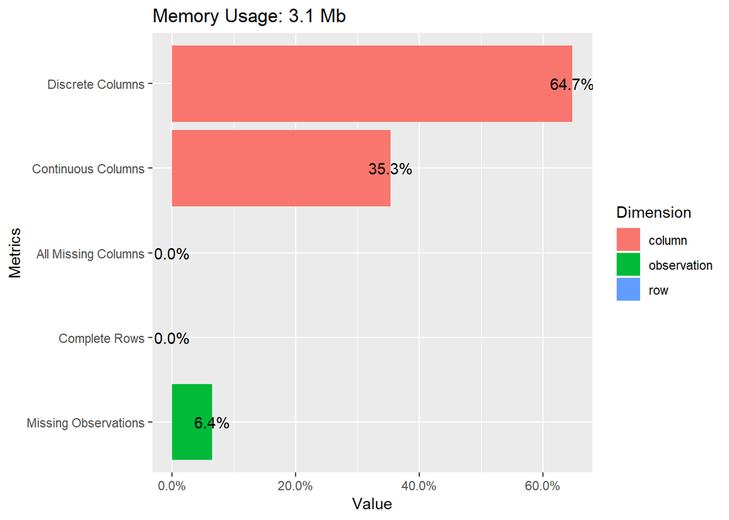

```r
plot_intro(df1)
```

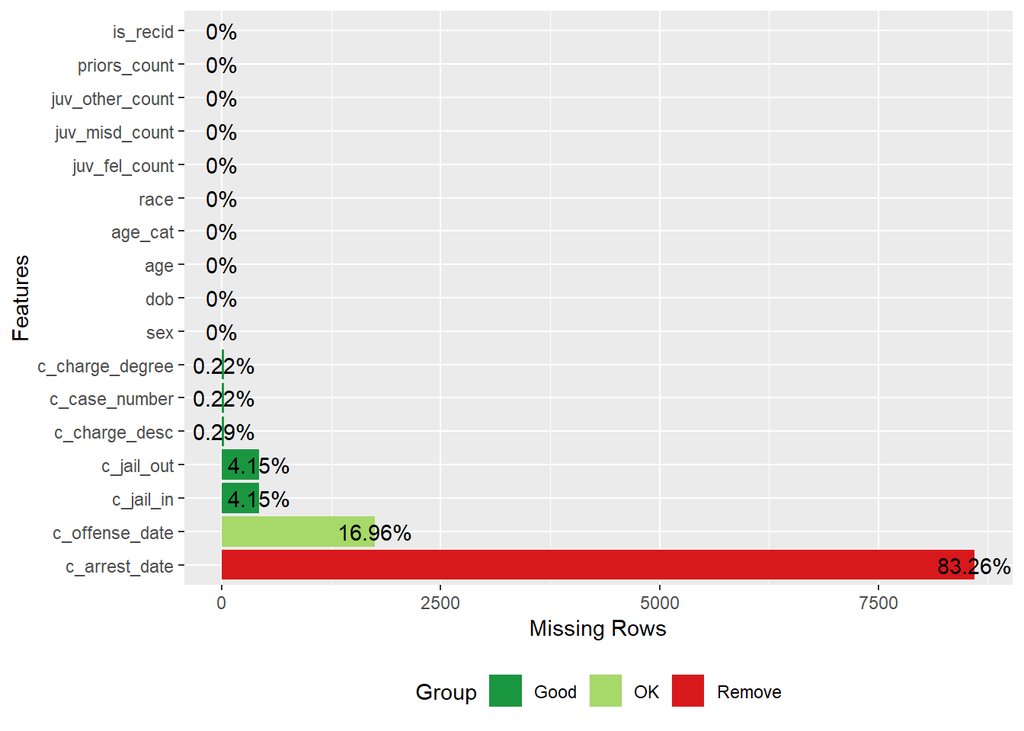

```r
plot_missing(df1)
```

Widać, że nie ma w ramce danych żadnego kompletnego wiersza oraz że zmienna arrest_date ma ponad 80% brakujących wartości przez co także usuwamy ją ze zbioru.

Dodaliśmy również kolumnę jail_long mówiącą o długości wyroki oraz grLong dzielącą obserwacje na 7 grup ze względu na długość odsiadki.

Po tych operacjach podzieliliśmy zbiór na treningowy i testowy, a natępnie przyjrzeliśmy się zbiorowi treningowemu.

```r
introduce(df2)
```

```
##   rows columns discrete_columns continuous_columns all_missing_columns
## 1 8269      18               12                  6                   0
##   total_missing_values complete_rows total_observations memory_usage
## 1                 2788          6655             148842      1983224
```

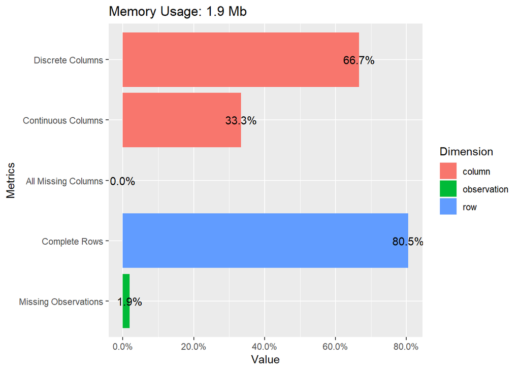

```r
plot_intro(df2)
```

# 2 Wizualizacja zmiennych

W celu wstępnej eksploracji zmiennych, które mogłyby być silnie skorelowane ze zmienną celu podzieliliśmy zbiór ze względu na zmienną is_recid i narysowaliśmy wykresy

## 2.1 Rasa

Kolor czerwony oznacza recydywistów

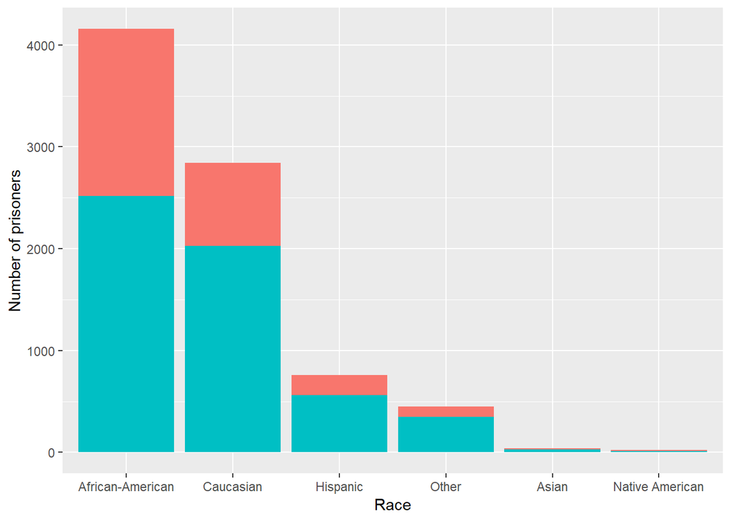

```r
p1_1
```

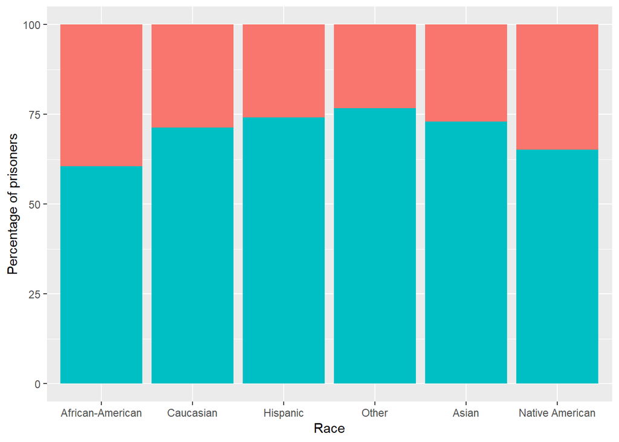

```r
p1_2
```

## 2.2 Długość odsiadki

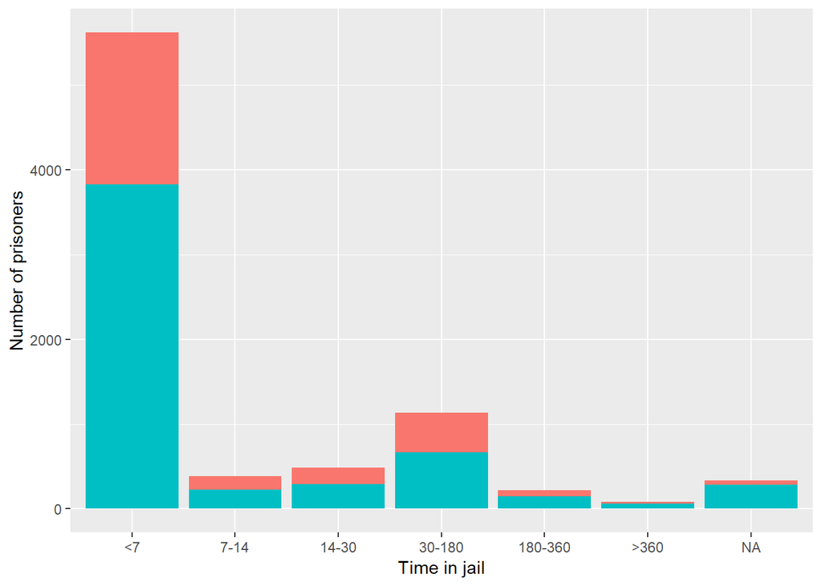

```r
p2_1
```

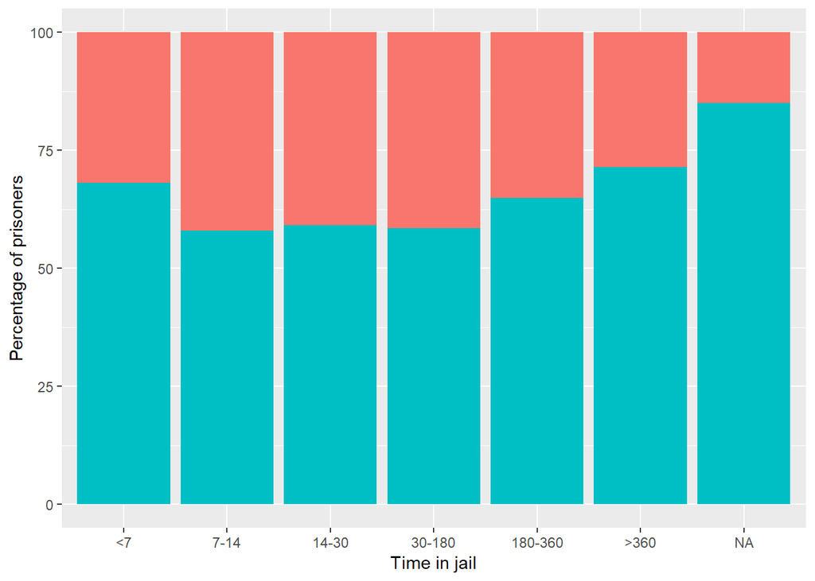

```r
p2_2
```

## 2.3 Grupa wiekowa

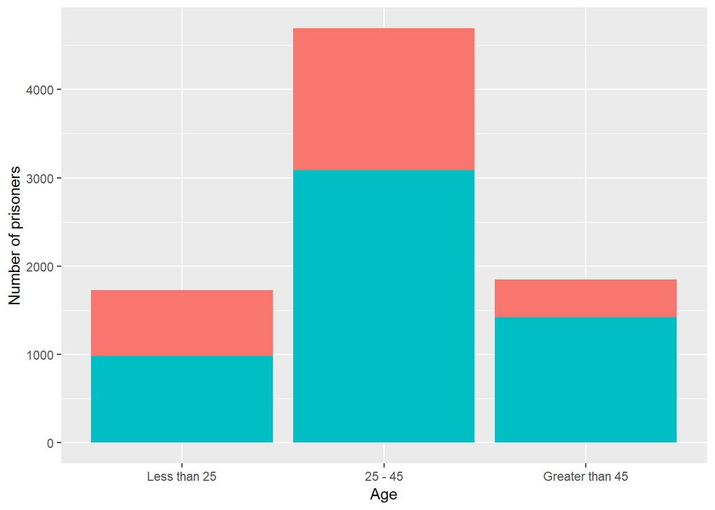

```r
p3_1
```

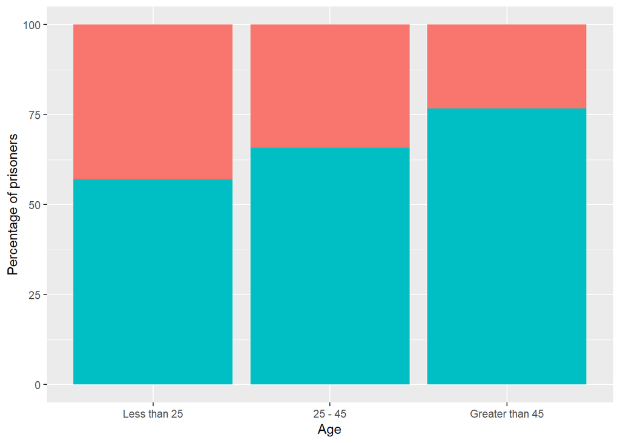

```r
p3_2
```

## 2.4 Stopień przestępstwa

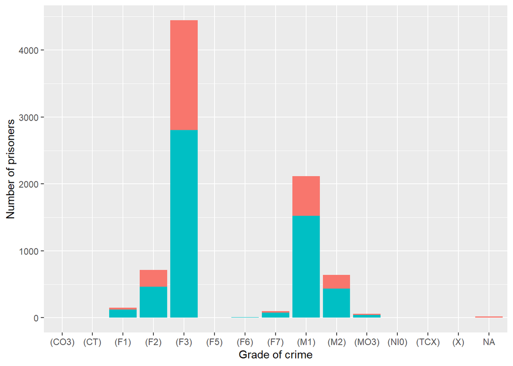

```r
#- Murder
#- Felony (1st degree) (F1) -> przestepstwo
#- Felony (2nd degree) (F2)
#- Felony (3rd degree) (F3)
#- Ungraded Felony (F3)
#- Misdemeanor (1st degree)(M1) -> wykroczenie
#- Misdemeanor (2nd degree)(M2)
#- Misdemeanor (3rd degree)(M3)
#- Ungraded Misdemeanor (Same as M3)
#- Summary Offenses
p4_1
```

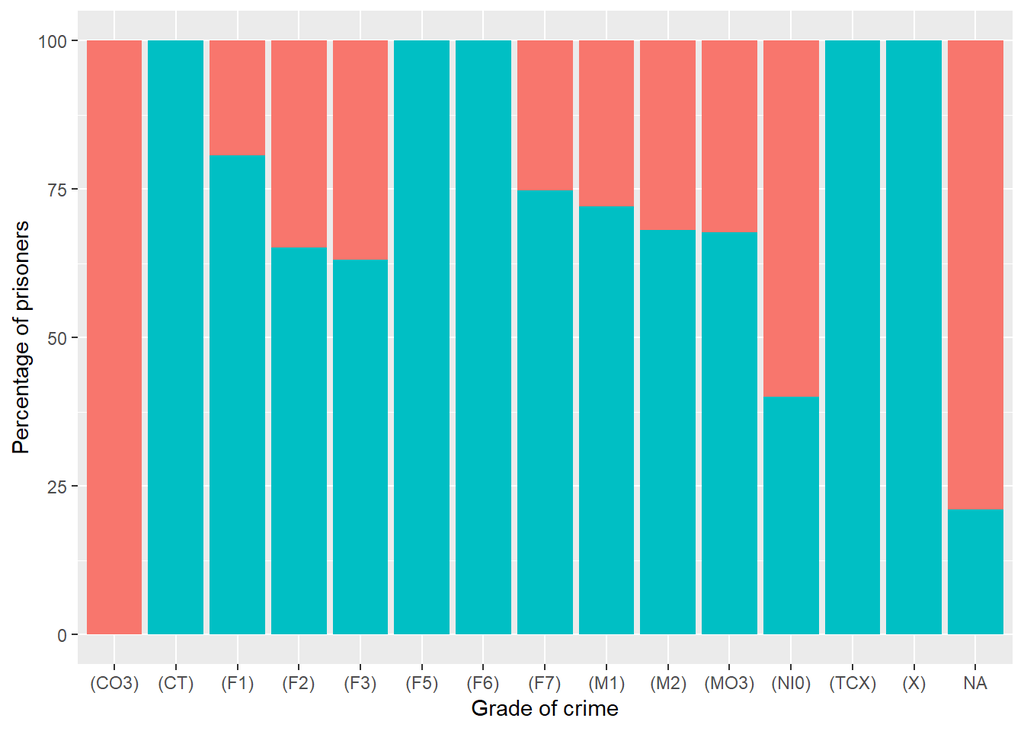

```r
p4_2
```

# 3 Korelacja zmiennych

Stworzyliśmy wykres korelacji poszczególnych zmiennych i kategorii. Najbardziej interesują nas powiązania ze zmienną celu.

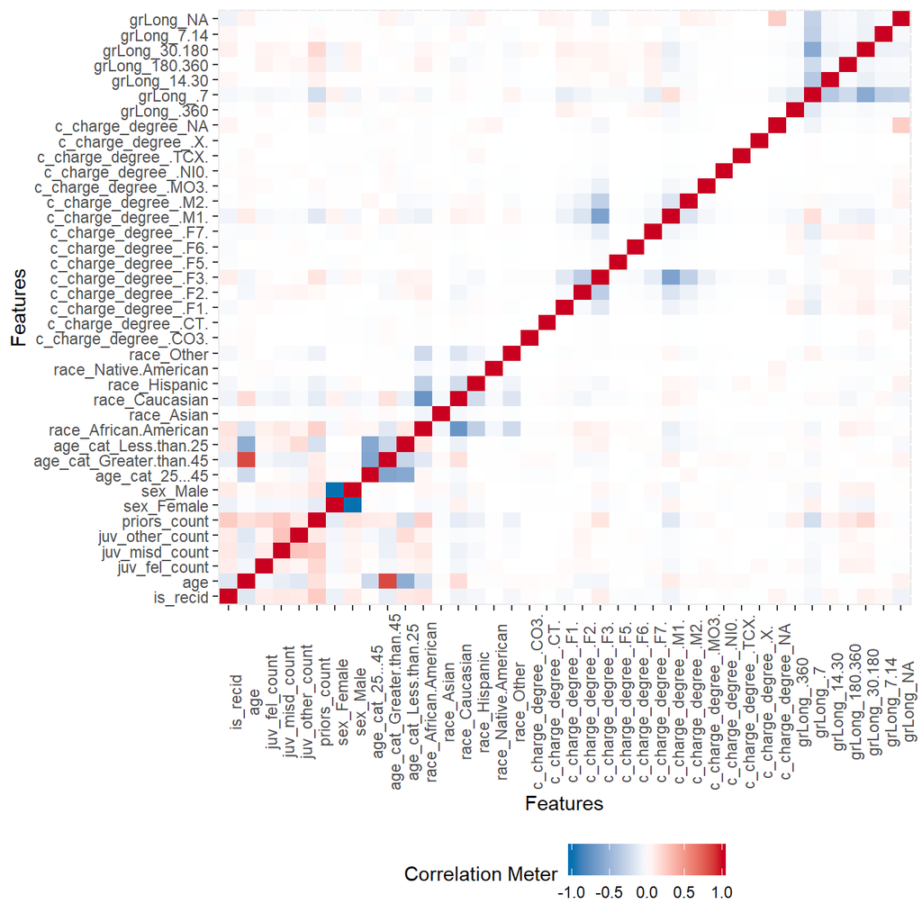

```r
p5
```

# 4 Benchmark

```r
daneTrv1 %>% filter(age_cat=="Less than 25" & juv_misd_count== ">1" & juv_other_count=="1") # <------ wynik do prezki
```

```
##       sex      age_cat             race juv_fel_count juv_misd_count
## 1    Male Less than 25        Caucasian             0             >1
## 2    Male Less than 25 African-American             0             >1
## 3    Male Less than 25            Other             0             >1
## 4    Male Less than 25 African-American             0             >1
## 5  Female Less than 25        Caucasian             0             >1
## 6    Male Less than 25 African-American             0             >1
## 7  Female Less than 25 African-American             0             >1
## 8    Male Less than 25            Other             0             >1
## 9    Male Less than 25 African-American             0             >1
## 10 Female Less than 25        Caucasian             0             >1
## 11   Male Less than 25         Hispanic             0             >1
## 12   Male Less than 25 African-American             0             >1
## 13   Male Less than 25        Caucasian             0             >1
##    juv_other_count priors_count is_recid grLong chargeGr
## 1                1          2-3        1     <7        b
## 2                1          4-6        1 30-180        b
## 3                1           >6        1     <7        b
## 4                1          4-6        1     <7        b
## 5                1          2-3        1     <7        b
## 6                1           >6        0 30-180        b
## 7                1          4-6        1     <7        c
## 8                1          2-3        1     <7        b
## 9                1          2-3        1     <7        b
## 10               1          2-3        1     <7        b
## 11               1          2-3        1 30-180        b
## 12               1          2-3        1   7-14        c
## 13               1          2-3        1     <7        b
```

Powyższa tabela zawiera informacje dotyczące kombinacji wartości zmiennych, które najczęściej przyjmowały wartość $is_recid$ równą 1.

Ponadto wykres reziduów pokazuje, że svm w odróżnieniu od regresji logistycznej i knn jest funkcją skokową.

Zrobiliśmy również benchmarki dla kilku różnych klasyfikatrów na ramkach danych bez naszych zmiennych i najlepsze wyniki otrzymaliśmy dla ramki ze wszystkimi naszymi wprowadzonymi zmianami.

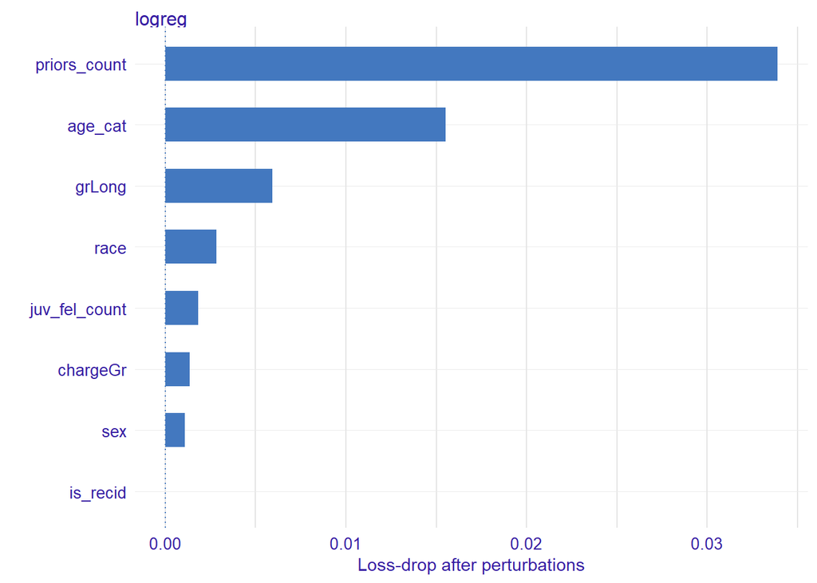

```r
plot1
```

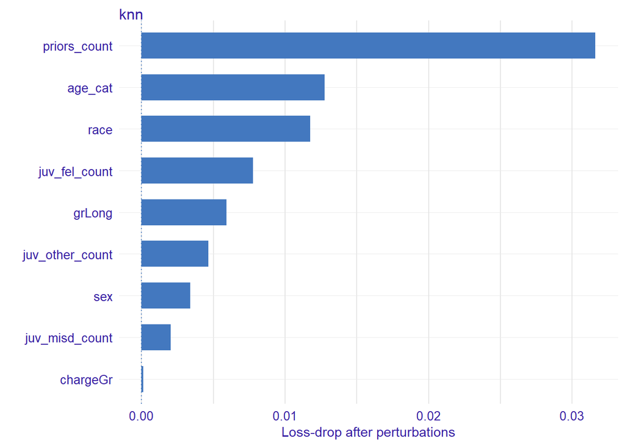

```r
plot2
```

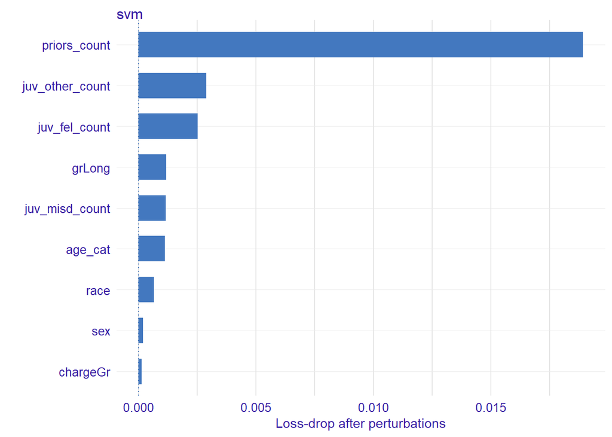

```r
plot3
```

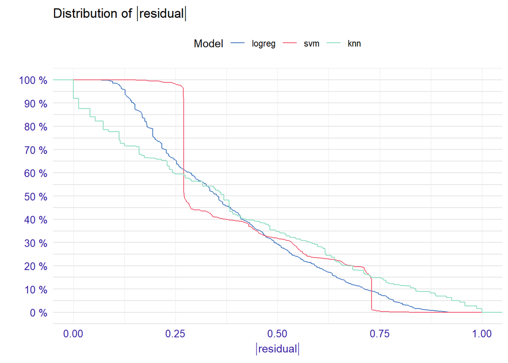

```r
plot4
```

```r
bmr
```

```
##     task.id         learner.id acc.test.mean auc.test.mean
## 1   classif      classif.rpart     0.6933140     0.6292261
## 2   classif classif.naiveBayes     0.6998547     0.7058938
## 3   classif        classif.svm     0.6878634     0.6886062
## 4  classif2      classif.rpart     0.6704215     0.5991607
## 5  classif2 classif.naiveBayes     0.6882267     0.6806101
## 6  classif2        classif.svm     0.6726017     0.6595980
## 7  classif3      classif.rpart     0.6791424     0.6183025
## 8  classif3 classif.naiveBayes     0.6791424     0.6535820
## 9  classif3        classif.svm     0.6791424     0.6384340
## 10 classif4      classif.rpart     0.6729651     0.6209534
## 11 classif4 classif.naiveBayes     0.6729651     0.6654327
## 12 classif4        classif.svm     0.6729651     0.5348942
## 13 classif5      classif.rpart     0.6765988     0.6115155
## 14 classif5 classif.naiveBayes     0.6744186     0.6657590
## 15 classif5        classif.svm     0.6765988     0.5592147
```

```r
bmr2
```

```
##   task.id    learner.id acc.test.mean auc.test.mean
## 1 classif        rpart1     0.6809593     0.6165481
## 2 classif        rpart2     0.6809593     0.6165481
## 3 classif        rpart3     0.6809593     0.6165481
## 4 classif classif.rpart     0.6809593     0.6165481
```

```r
bmr3
```

```
##   task.id learner.id acc.test.mean auc.test.mean
## 1 classif     rfor10     0.6896802     0.6578742
## 2 classif     rfor50     0.6911337     0.6702389
## 3 classif    rfor100     0.6962209     0.6739641
## 4 classif    rfor500     0.6965843     0.6748224
## 5 classif   rfor1000     0.6965843     0.6798788
```

# 5 Użyta metoda ewaluacji

```r
# Stosunek "1" do "0" w naszych danych
table(dane$is_recid)
```

```
##
##    0    1
## 6858 3473
```

# 6 Szukanie hiperparametrów

Do ustalania hipermarametrów wykorzystaliśmy funkcję $tuneParams$, która zwracała jako wynik najlepsze parametry z tych, które były testowane. Kolejne modele sprawdzaliśmy według następującego schematu:

```r
#6
getParamSet(makeLearner("classif.ada"))
ps_g6 = makeParamSet(
  makeNumericParam("cp", lower = 0, upper = 1),
  makeDiscreteParam("type", values = c("discrete","real","gentle")),
  makeDiscreteParam("loss", values = c("exponential","logistic")),
  makeDiscreteParam("max.iter", values = 1:200),
  makeDiscreteParam("minsplit", values = 1:40),
  makeDiscreteParam("maxdepth", values = 1:30),
  makeDiscreteParam("xval", values = 5:20)
)

ctrl_g6 = makeTuneControlRandom(maxit = 20L)

res_g6 = tuneParams("classif.ada", task = classif_task, resampling = rdesc,
                  par.set = ps_g6, control = ctrl_g6)

lrn_g6 = setHyperPars(makeLearner("classif.ada"), par.vals = res_g6$x)
m_g6 = train(lrn_g6, classif_task)
p_g6 <- predict(m_g6, newdata = daneTest)
performance(p_g6,measures = acc)
```

# 7 Przetestowane modele

Klasyfikatory, dla których wyszukiwaliśmy optymalne parametry i badaliśmy wyniki to:

1. Support Vector Machine (svm)
2. Adabag Boosting (boosting)
3. Bayesian Additive Regression Trees (bartMachine)
4. ada Boosting (ada)
5. GLM with Lasso or Elasticnet Regularization (cvglmnet)
6. h2o.deeplearning
7. Flexible Discriminant Analysis (earth)
8. h20.randomForest
9. Logistic Regression (logreg)
10. Regularized Discriminant Analysis (rda)

# 8 Wyniki i wybór modelu

Nalepsze wyniki otrzymaliśmy dla Adabag Boostingu, Regularized Discrimant Analysis, GLM with Lasso oraz regresji logistycznej. Wynik regresji zależał jednak mocno od seeda.

```r
#Wyniki dla rda
rda: 0.6997494
$lambda 0.9651718
$gamma 0.01000534
$train.fraction 0.4822396
$fold 2
$K 51
$alpha 3.2523

#Wyniki dla boosting
boosting: 0.7042607
$cp 0.01753475
$mfinal 100
$minsplit 15
$maxdepth 30
$xval 12

#Wyniki dla cvglmnet
cvglmnet: 0.7132207
$nlambda 131
$mxit=21
$nfolds=22
$exmx=243

#Wyniki dla logreg
dla seed = 125
logreg: 0.712782

dla seed = 1234
logreg: 0.6916342
```

# 9 Wybrany model

Lasso Regression

Więcej informacji na temat dokładnego działania modelu: https://cran.r-project.org/web/packages/glmnet/glmnet.pdf